# AEROSP 520 Compressible Flow: Homework 3

Jason Chen

## Problem 1

Given a pitot tube in both subsonic and supersonic flow conditions, consider the following:

### Question (1): What is the property (pressure) measured by this device, for either case?

Generally, in both cases, the pitot tube is measuring the stagnation pressure of the incoming flow, as any kinetic energy (due to the flow velocity at incoming Mach number $M_1$) is isentropcially converted back into internal energy modes in the fluid. It is notable though that in the supersonic case, the presence of a normal shock, which by definition is irreversible and translates to a loss of total useful energy (total pressure and temperature, although total enthalpy is preserved because it is adiabatic and does no work), means that the supersonic pitot tube measures the total thermodynamic state after the normal shock, not of the freestream. In terms of Mach number, we know that for a higher Mach number, the stronger the shock, and therefore by comparing the distance of the shock $\delta$ to what the manometer measures, we can know more about the freestream Mach number and other properties.

In the supersonic case, the above equation is still valid but instead gives us the state downstream of the normal shock, which we will denote as state (2). In other words, the equation above gives $p_{pt} = f(M_2, p_{0,2})$. To relate state (2) to the freestream conditions, we use the normal shock jump relations, which once again assumes a CPG. We can get the upstream Mach number directly from the downstream Mach number: $$ \boxed{M_2 = \sqrt{\frac{M_1^{2}(\gamma-1)+2}{2\gamma M_1^{2}-(\gamma-1)}}} $$ With the upstream Mach number $M_1$, we can solve for the stagnation pressure ratio, and therefore the upstream stagnation pressure: $$ \boxed{ \frac{p_{02}}{p_{01}} = \left( \frac{\tfrac{\gamma+1}{2} M_1^{2}} {1 + \tfrac{\gamma-1}{2} M_1^{2}} \right)^{\frac{\gamma}{\gamma-1}} \left( \frac{1} {\tfrac{2\gamma}{\gamma+1} M_1^{2} - \tfrac{\gamma-1}{\gamma+1}} \right)^{\frac{1}{\gamma-1}} } $$

Finally, given the stagnation pressure and Mach number, we can solve for the upstream static pressure $p_1$ like before. Combining the above three equations we have the pitot measurement as a function of only state (1) conditions, $p_{pt} = f(p_{0,1}, M_1)$.

### Question (2): Modeling the supersonic boundary layer

Plot the following:

- $p_{pt}/p_1$
- $T/T_1$
- $p_{pt}/p_{0,1}$
- $M_1$

The approach is as follows: the first equation gives us the velocity at distance $y$ purely as a function of $y$ and known constants: $$ \frac{u(y)}{U_e} = \sin{\left( \frac{y}{\delta}\frac{\pi}{2} \right)} $$ The adiabatic wall temperature is a function of known constants as well (for a given iteration). Let $c_p$ be constant under the CPG assumption, and evaluated assuming air as the composition $c_p = 1005 \textrm{ J/kg/K}$. $$ T_{aw} = T_e + r\frac{U_e^2}{2 c_p} $$ Finally, the temperature at a particular point is: $$ \frac{T}{T_w} = 1+\frac{T_{aw}-T_w}{T_w} \frac{u}{U_e} - \frac{u^2}{2 c_p T_w} $$ The temperature we solve for above is the true temperature at a certain radial location in the boundary layer, and from velocity and temperature we know the Mach number of the flow.

To find the pitot pressure to stagnation pressure ratio, we are told the pressure across the boundary layer is equivalent to that at the freestream. We can set $p_1$ to a dummy, constant value (say, 1 MPa) since its value will be normalized out later, and use the Mach number $M_1$ to find stagnation pressure $p_{0,1}$ at a given $y$. Then, using the shock jump relation, stagnation pressure and Mach number $p_{0,2}$ and $M_2$ can be found downstream of the shock. **$p_{pt}$ is equivalent to $p_{0,2}$.** $$ \frac{p_{pt}}{p_{01}} = \left( \frac{\tfrac{\gamma+1}{2} M_1^{2}} {1 + \tfrac{\gamma-1}{2} M_1^{2}} \right)^{\frac{\gamma}{\gamma-1}} \left( \frac{1} {\tfrac{2\gamma}{\gamma+1} M_1^{2} - \tfrac{\gamma-1}{\gamma+1}} \right)^{\frac{1}{\gamma-1}} $$

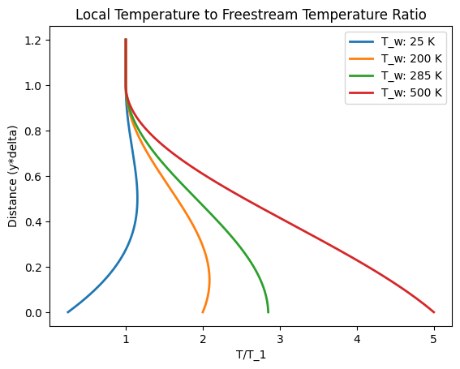

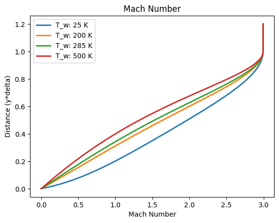

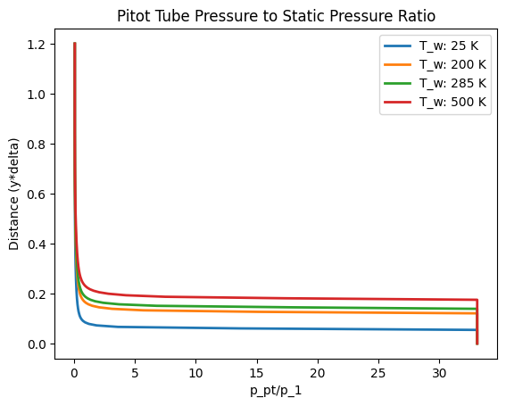

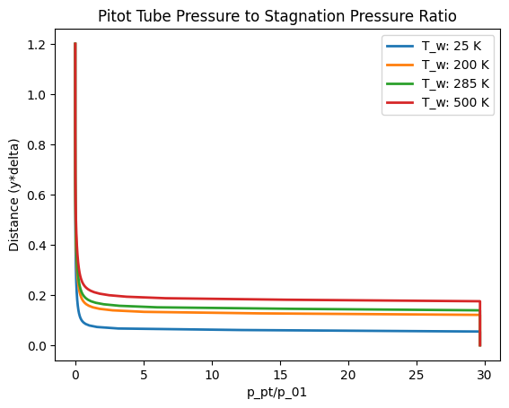

```python
import numpy as np
import matplotlib.pyplot as plt

u_e = 600
T_e = 100
Pr = 1
wall_T = [25, 200, 285, 500]
y = np.linspace(0, 1.2, 200)
c_p = 1005
gamma = 1.4
R = 287
T_ratios = []
M_numbers = []
ppt_static_ratios = []
ppt_stagnation_ratios = []
for T_w in wall_T:
    T_aw = T_e + (Pr**0.5) * (u_e**2)/(2 * c_p)
    u_y = u_e * np.sin(y * np.pi/2)
    T = T_w * (1 + ((T_aw-T_w)/T_w) * (u_y/u_e) - (u_y**2)/(2 * c_p * T_w))
    for i in range(np.argmax(y > 1.0), len(y), 1):
        T[i] = T_e
        u_y[i] = u_e
    T_ratios.append(T/T_e)
    M_1 = u_y/np.sqrt(gamma * R * T)
    M_numbers.append(M_1)
    M_1 = np.where(M_1 < 0.4, 0.4, M_1)
    term_1 = (((gamma+1)/2) * (M_1**2))/(1+(((gamma+1)/2) * (M_1**2)))
    term_2 = ((2*gamma)/(gamma+1)) * (M_1**2) - ((gamma-1)/(gamma+1))
    ppt_p01 = (term_1**(gamma/(gamma-1))) * (term_2**(-1/(gamma-1)))
    ppt_p1 = ppt_p01 * ((1 + ((gamma-1)/2)*(M_1**2)) ** (gamma/(gamma-1)))
    ppt_static_ratios.append(ppt_p1)
    ppt_stagnation_ratios.append(ppt_p01)

plt.figure()
for i, T_w in enumerate(wall_T):
    plt.plot(T_ratios[i], y, label=f"T_w: {T_w} K", lw=2)
plt.xlabel('T/T_1')
plt.ylabel('Distance (y*delta)')
plt.title('Local Temperature to Freestream Temperature Ratio')
plt.legend()
plt.show()

plt.figure()
for i, T_w in enumerate(wall_T):
    plt.plot(M_numbers[i], y, label=f"T_w: {T_w} K", lw=2)
plt.xlabel('Mach Number')
plt.ylabel('Distance (y*delta)')
plt.title('Mach Number')
plt.legend()
plt.show()

plt.figure()
for i, T_w in enumerate(wall_T):
    plt.plot(ppt_static_ratios[i], y, label=f"T_w: {T_w} K", lw=2)
plt.xlabel('p_pt/p_1')
plt.ylabel('Distance (y*delta)')
plt.title('Pitot Tube Pressure to Static Pressure Ratio')
plt.legend()
plt.show()

plt.figure()
for i, T_w in enumerate(wall_T):
    plt.plot(ppt_stagnation_ratios[i], y, label=f"T_w: {T_w} K", lw=2)
plt.xlabel('p_pt/p_01')
plt.ylabel('Distance (y*delta)')
plt.title('Pitot Tube Pressure to Stagnation Pressure Ratio')
plt.legend()
plt.show()
```

## Problem 2

The justification for this problem is done in paper.

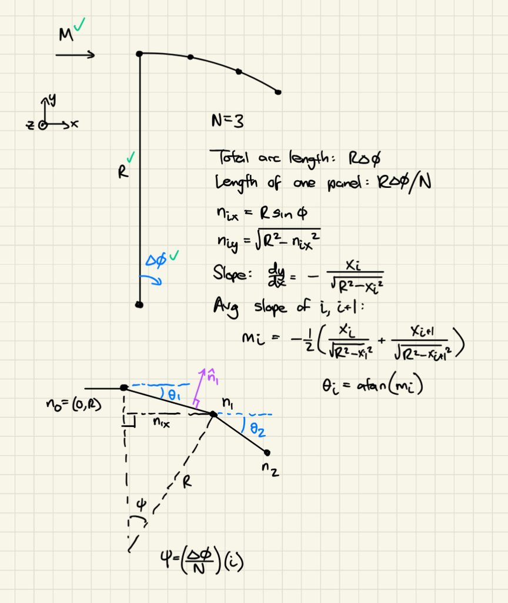

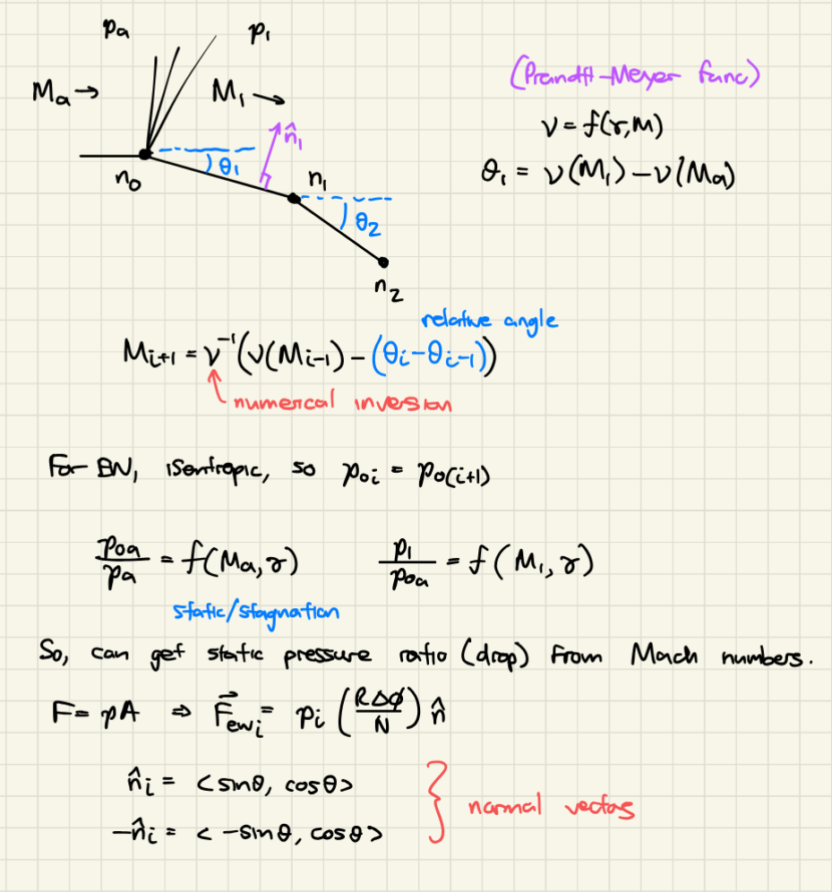

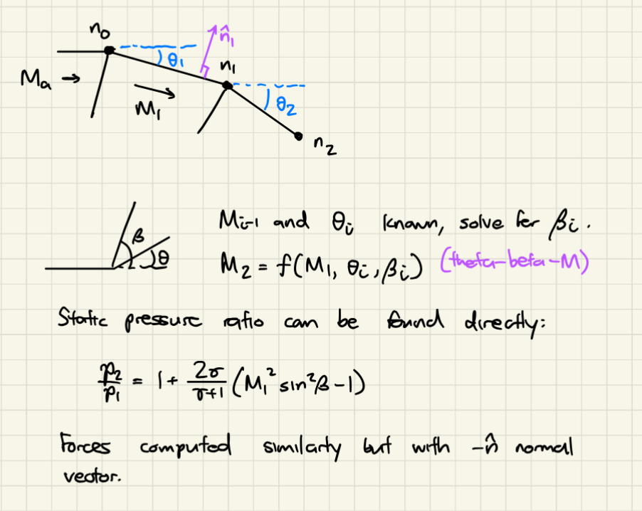

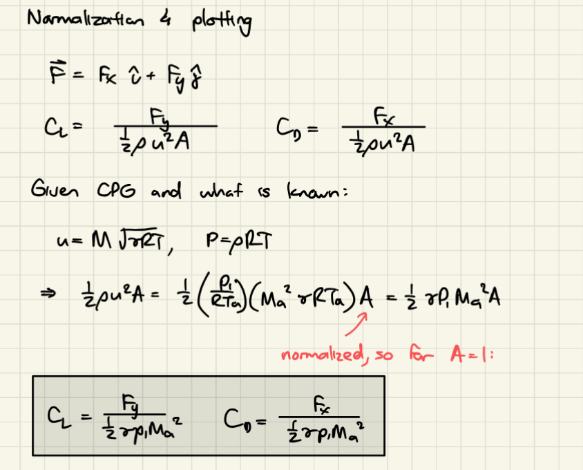

Finally, the plots:

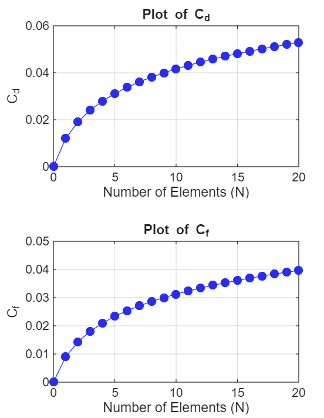

## Problem 3

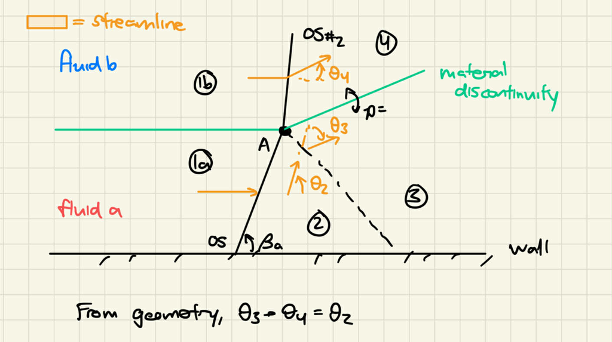

The situtation and types of waves that appear are illustrated above. Downstream of the oblique shock in fluid a, the pressure rises and the flow is deflected counterclockwise by an angle $\theta_2$. The pressures of fluids a and b must be equal, and their velocity directions must be parallel, so additional waves form to match this condition.

Because the first, left-running wave (initiating OS) deflects the flow, changing the velocity vector’s direction, an oblique shock develops in fluid b to turn the flow counterclockwise by some angle $\theta_4$. If no other waves formed, $\theta_4$ would have to equal $\theta_2$ so that the velocities remain parallel. However, we require another wave to increase the pressure in fluid a until $P_4 = P_3$. To achieve this, a right-running oblique shock forms in fluid a, turning the flow clockwise by an angle $\theta_3$. Since this deflection is clockwise, the velocities become parallel when $\theta_3 + \theta_4 = \theta_2$. The idea of solving this problem is that $\theta_3$ can then be determined iteratively so that both the velocity directions and pressures satisfy $P_3 = P_4$.

```python
from scipy.integrate import quad
from scipy.optimize import root_scalar

def theta_beta_m(M, theta, gam):
    b = 1e-3
    while b > 0:
        eq = 2/np.tan(np.deg2rad(b)) * ((M**2 * np.sin(np.deg2rad(b))**2 - 1)/(M**2 * (gam + np.cos(np.deg2rad(2*b))) + 2))
        if abs(np.tan(np.deg2rad(theta)) - eq) < 0.0005:
            return b
        b += 1e-4
    return None

def prandtl_meyer(M, gam):
    func = lambda m: np.sqrt(m**2 - 1) / ((1 + ((gam - 1)/2) * m**2) * m)
    VM, _ = quad(func, 1, M)
    return np.rad2deg(VM)

def oblique_shock(M1, beta_a, gam):
    Mn = M1 * np.sin(np.deg2rad(beta_a))
    p_ratio = 1 + ((2 * gam) / (gam + 1)) * (Mn**2 - 1)
    theta = np.rad2deg(np.arctan(
        2 / np.tan(np.deg2rad(beta_a)) *
        ((M1**2 * np.sin(np.deg2rad(beta_a))**2 - 1) /
         (M1**2 * (gam + np.cos(np.deg2rad(2*beta_a))) + 2))
    ))
    Mn2 = np.sqrt((Mn**2 + 2/(gam - 1)) / ((2*gam/(gam - 1)) * Mn**2 - 1))
    M2 = Mn2 / np.sin(np.deg2rad(beta_a - theta))
    return p_ratio, theta, M2

# Conditions in 1a and 1b
P1 = 1  # atm
T1 = 300  # K
Ub = 1200  # m/s
Ua = Ub
beta_a = 34.85  # degrees
Ru = 8.314
gamma_a = 1.4
gamma_b = 5/3
Wa = 28.9
Wb = 40
Ra = (Ru / Wa) * 1000   # J/kg/K
Rb = (Ru / Wb) * 1000   # J/kg/K
Ma = Ua / np.sqrt(gamma_a * Ra * T1)
Mb = Ub / np.sqrt(gamma_b * Rb * T1)
# Region 2
p2ratio, theta2, M2 = oblique_shock(Ma, beta_a, gamma_a)
p2 = p2ratio * P1
# Region 3 and 4
init_theta3 = 2  # degrees
theta4 = theta2 - init_theta3

while abs(theta2) > abs(init_theta3):
    bet = theta_beta_m(Mb, theta4, gamma_b)
    p4ratio, theta4_calc, M4_th = oblique_shock(Mb, bet, gamma_b)
    p4_th = p4ratio * P1
    bet = theta_beta_m(M2, init_theta3, gamma_a)
    p3ratio, theta3_err, M3_rd = oblique_shock(M2, bet, gamma_a)
    p3_oblique = p3ratio * p2
    if abs(p4_th - p3_oblique) < 0.002:
        theta3 = init_theta3
        theta4 = theta2 - theta3
        M4 = M4_th
        M3 = M3_rd
        p3 = p3_oblique
        p4 = p4_th
        break
    else:
        init_theta3 += 0.001
        theta4 = theta2 - init_theta3
```

The solution for $u_a = 1200 \textrm{m/s}$ and $\beta_a = 34.8 \textrm{ degrees}$:

| Region | Pressure (atm) | Mach Number | Flow Deflection (deg) |
| --- | --- | --- | --- |
| **1a** | 1.00 | 3.45 | 0.00 |
| **1b** | 1.00 | 3.72 | 0.00 |
| **2 (Fluid a)** | 4.37 | 2.27 | 20.0 |
| **3 (Fluid a)** | 5.02 | 2.18 | 2.29 |
| **4 (Fluid b)** | 5.02 | 2.20 | 17.7 |

I did not have time to run the new assumptions, but my intuition tells me that the solution does indeed change. Changing the species will affect the maximum deflection angles possible and what is "achievable" my certain types of waves. Particularly, how they can retain the matching requirement across the material boundary. We may need to reformulate the problem, i.e. change what the shock intersection actually produces (rather than an OS in fluid b, for example).